# Promoter vs gene-body methylation

Do the two regions relate to expression with opposite sign? TCGA-THCA

17 August 2026

```r
knitr::opts_chunk$set(echo = TRUE, message = FALSE, warning = FALSE,
                      dev = "png", dpi = 140, fig.align = "center")
suppressMessages(library(ggplot2))
theme_set(theme_minimal(base_size = 12) +
          theme(panel.grid.minor = element_blank(),
                plot.title = element_text(face = "bold", size = 13),
                plot.subtitle = element_text(colour = "grey35", size = 10.5),
                strip.text = element_text(face = "bold")))
COL_PROM <- "#2c7fb8"   # promoter
COL_BODY <- "#d95f0e"   # gene body
COL_NEG  <- "#2c7fb8"; COL_POS <- "#d7301f"; COL_NULL <- "grey80"
RES <- ".."             # repo root, relative to reports/

## region vocabularies, matching methylation_scores() in R/prizes.R
PROM <- c("TSS1500", "TSS200", "5'UTR", "1stExon")
BODY <- c("Body", "3'UTR", "ExonBnd")
```

# The question

`pcsfomics` scores promoter and gene-body methylation **separately**, and the stated reason (design decision #2 in `CLAUDE.md`) is that their expected relationship to expression has **opposite sign**:

> Promoter methylation is typically silencing; gene-body methylation is often positively correlated with expression. Pooling them cancels signal.

That assumption is load-bearing. It shapes `methylation_scores()`, which splits the two contexts, and it shapes `concordance_bonus()`, which awards full credit to *promoter-hyper + expression-down* and partial credit to *body-hyper + expression-up* as “the expected direction”.

The assumption comes from the literature and had never been checked against this cohort. This report checks it, three ways:

1. **Directly** — per-gene correlation between methylation change and expression change, computed separately for each region.
2. **Through an orthogonal readout** — inferred transcription-factor activity, which measures a TF’s functional output from its regulon rather than from its own mRNA.
3. **Jointly** — whether the two regions carry independent information at all.

The prediction, if the assumption holds, is a clean **double dissociation**: promoter methylation negatively related to expression and activity, body methylation positively related to both.

# Data and region definitions

TCGA-THCA (papillary thyroid carcinoma): Illumina 450K methylation and STAR RNA-seq counts, tumour versus adjacent normal. The 450K annotation assigns each probe to one or more genes with a matching genomic context.

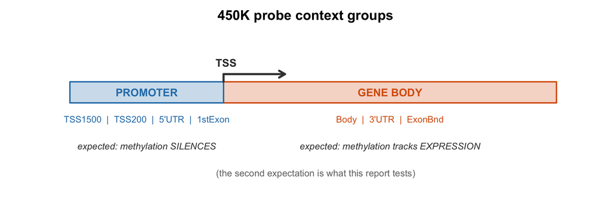

450K region labels and how they are grouped here. The promoter group spans the transcription start site; the body group covers the transcribed length. These are the same vocabularies methylation_scores() uses.

```r
par(mar = c(0.5, 0.5, 2.2, 0.5))
plot(NA, xlim = c(-0.06, 1.02), ylim = c(-0.55, 1), axes = FALSE,
     xlab = "", ylab = "", main = "450K probe context groups")
## gene body bar
rect(0.32, 0.30, 0.97, 0.52, col = adjustcolor(COL_BODY, .25), border = COL_BODY, lwd = 2)
## promoter bar
rect(0.02, 0.30, 0.32, 0.52, col = adjustcolor(COL_PROM, .25), border = COL_PROM, lwd = 2)
## TSS arrow
arrows(0.32, 0.60, 0.44, 0.60, length = 0.10, lwd = 3, col = "grey25")
segments(0.32, 0.52, 0.32, 0.60, lwd = 3, col = "grey25")
text(0.325, 0.72, "TSS", font = 2, cex = 0.95, col = "grey20")
text(0.17, 0.41, "PROMOTER", font = 2, col = COL_PROM, cex = 0.95)
text(0.645, 0.41, "GENE BODY", font = 2, col = COL_BODY, cex = 0.95)
text(0.17, 0.12, paste(PROM, collapse = "  |  "), cex = 0.8, col = COL_PROM)
text(0.645, 0.12, paste(BODY, collapse = "  |  "), cex = 0.8, col = COL_BODY)
text(0.17, -0.16, "expected: methylation SILENCES", cex = 0.82, col = "grey25", font = 3)
text(0.645, -0.16, "expected: methylation tracks EXPRESSION", cex = 0.82, col = "grey25", font = 3)
text(0.5, -0.44, "(the second expectation is what this report tests)",
     cex = 0.82, col = "grey45")
```

Probe-to-region assignment has one trap worth stating, because getting it wrong silently scrambles this entire analysis. `UCSC_RefGene_Name` and `UCSC_RefGene_Group` are **positionally aligned** semicolon-delimited fields: entry *i* of one belongs with entry *i* of the other. Splitting them independently mismatches genes to regions. `annotate_probes()` unpacks them pairwise.

```r
## How the cached tables below were produced. Guarded by file.exists() in the
## real scripts; shown here in full because the region split is the step that
## has to be right.
ann <- minfi::getAnnotation(IlluminaHumanMethylation450kanno.ilmn12.hg19)
gs <- strsplit(as.character(ann$UCSC_RefGene_Name),  ";", fixed = TRUE)
rs <- strsplit(as.character(ann$UCSC_RefGene_Group), ";", fixed = TRUE)
n  <- lengths(gs)
keep <- n > 0 & n == lengths(rs)            # pairwise, never independently
map <- data.frame(probe  = rep(rownames(ann)[keep], n[keep]),
                  gene   = unlist(gs[keep], use.names = FALSE),
                  region = unlist(rs[keep], use.names = FALSE))

## differential methylation, tumour vs normal, paired on patient, tested on
## M-values and reported as delta beta (see R/tcga_input.R)
dm  <- diff_methylation(beta, group, patient, paired = TRUE)
dmr <- annotate_probes(dm, anno)

## one row per gene per region group: the probe with the largest |delta beta|,
## matching how methylation_scores() aggregates (max, not sum -- summing would
## reward CpG density rather than regulatory relevance)
gene_level <- function(regs) {
  d <- dmr[dmr$region %in% regs, ]
  d <- d[order(-abs(d$delta_beta)), ]
  d[!duplicated(d$gene), ]
}
promoter <- gene_level(PROM)   # -> results/promoter_methylation.tsv
body     <- gene_level(BODY)   # -> results/body_methylation.tsv
```

```r
prom <- read.delim(file.path(RES, "results/promoter_methylation.tsv"), stringsAsFactors = FALSE)
body <- read.delim(file.path(RES, "results/body_methylation.tsv"),     stringsAsFactors = FALSE)

methyl_sig_cutoff=1e-9
sig <- function(d) sum(d$padj < methyl_sig_cutoff & abs(d$delta_beta) > 0.1, na.rm = TRUE)
meth_data_tbl <- data.frame(
  Region = c("Promoter", "Gene body"),
  `Genes measured` = c(nrow(prom), nrow(body)),
  sig = c(sig(prom), sig(body)),
  `Median dBeta` = sprintf("%+.4f", c(median(prom$delta_beta, na.rm = TRUE),
                                      median(body$delta_beta, na.rm = TRUE))),
  check.names = FALSE)
colnames(meth_data_tbl) <- c("Region","Genes measured",paste0("FDR<",methyl_sig_cutoff," & |dBeta|>0.1"),"Median dBeta")
knitr::kable(meth_data_tbl,
  caption = "Differential methylation by region, tumour vs normal.")
```

Differential methylation by region, tumour vs normal.

| Region | Genes measured | FDR<1e-09 & \|dBeta\|>0.1 | Median dBeta |
| --- | --- | --- | --- |
| Promoter | 19062 | 637 | -0.0039 |
| Gene body | 17141 | 1117 | -0.0021 |

# 1. The direct test: cis coupling

The cleanest way to ask whether methylation tracks expression is to correlate them **within patients**. For each gene, take the 50 patients with both a tumour and a normal sample in *both* assays, and correlate the per-patient change in methylation against the per-patient change in expression.

This paired-delta form matters. Correlating absolute levels across samples answers a different question — it measures between-patient variation, which in this cohort is dominated by 505 tumours against 50 normals. (Computed both ways, the absolute-level versions agree with each other at Spearman 0.971 while agreeing with the paired version at only 0.43.) The paired form removes between-patient baseline entirely, the same reason the differential expression design blocks on patient.

```r
## per gene: rank correlation of (tumour - normal) methylation against
## (tumour - normal) expression, across the 50 patients paired in both assays
dB <- beta_tumour[, pats] - beta_normal[, pats]     # delta beta, best probe in region
dE <- expr_tumour[, pats] - expr_normal[, pats]     # delta logCPM
rho <- mapply(function(i) {
  ok <- is.finite(dB[i, ]) & is.finite(dE[i, ])
  if (sum(ok) < 25) return(NA_real_)
  cor(rank(dB[i, ok]), rank(dE[i, ok]))
}, seq_len(nrow(dB)))
```

```r
cp <- read.delim(file.path(RES, "results/cis_correlation_paired.tsv"), stringsAsFactors = FALSE)
cb <- read.delim(file.path(RES, "results/cis_correlation_body.tsv"),   stringsAsFactors = FALSE)
cis <- rbind(
  data.frame(gene = cp$gene, rho = cp$rho_paired, padj = cp$padj, region = "Promoter"),
  data.frame(gene = cb$gene, rho = cb$rho_body,   padj = cb$padj, region = "Gene body"))
cis$region <- factor(cis$region, levels = c("Promoter", "Gene body"))

summ <- do.call(rbind, lapply(split(cis, cis$region), function(d) data.frame(
  Region = d$region[1],
  Genes = nrow(d),
  `Median rho` = sprintf("%+.3f", median(d$rho, na.rm = TRUE)),
  `% negative` = sprintf("%.0f%%", 100 * mean(d$rho < 0, na.rm = TRUE)),
  `Strong negative` = sum(d$rho < -0.2 & d$padj < 0.05, na.rm = TRUE),
  `Strong positive` = sum(d$rho >  0.2 & d$padj < 0.05, na.rm = TRUE),
  check.names = FALSE)))
knitr::kable(summ, row.names = FALSE,
  caption = "Cis coupling by region. If the sign assumption held, the gene-body row would be dominated by POSITIVE correlations.")
```

Cis coupling by region. If the sign assumption held, the gene-body row would be dominated by POSITIVE correlations.

| Region | Genes | Median rho | % negative | Strong negative | Strong positive |
| --- | --- | --- | --- | --- | --- |
| Promoter | 13286 | -0.040 | 59% | 545 | 59 |
| Gene body | 12869 | -0.030 | 56% | 555 | 145 |

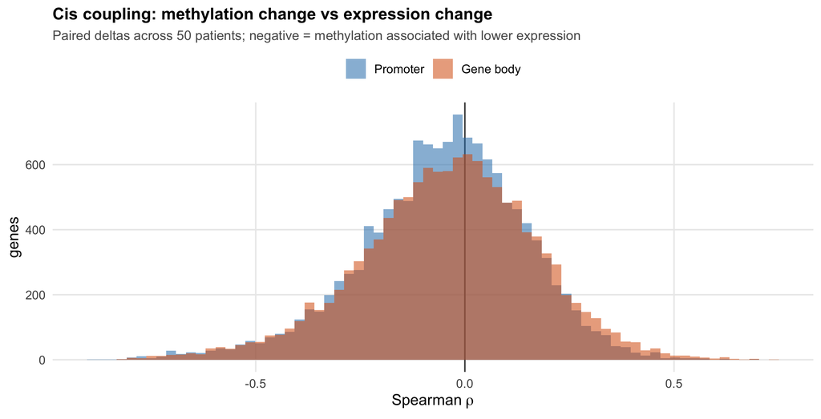

Per-gene cis correlation between methylation change and expression change. Both distributions sit left of zero. The gene-body distribution is shifted slightly toward zero relative to the promoter, but it is not mirrored: body methylation is predominantly NEGATIVELY coupled to expression, not positively.

```r
ggplot(cis, aes(rho, fill = region)) +
  geom_vline(xintercept = 0, colour = "grey30") +
  geom_histogram(bins = 70, alpha = 0.55, position = "identity", colour = NA) +
  scale_fill_manual(values = c(Promoter = COL_PROM, `Gene body` = COL_BODY), name = NULL) +
  labs(title = "Cis coupling: methylation change vs expression change",
       subtitle = "Paired deltas across 50 patients; negative = methylation associated with lower expression",
       x = expression(Spearman~rho), y = "genes") +
  theme(legend.position = "top")
```

```r
mm <- merge(cp[, c("gene","rho_paired")], cb[, c("gene","rho_body")], by = "gene")
mm <- mm[is.finite(mm$rho_paired) & is.finite(mm$rho_body), ]
w  <- wilcox.test(mm$rho_paired, mm$rho_body, paired = TRUE)
ct <- cor.test(mm$rho_paired, mm$rho_body, method = "spearman")
knitr::kable(data.frame(
  Quantity = c("Genes with both regions measured",
               "Median promoter rho", "Median body rho",
               "Paired Wilcoxon, promoter vs body", "Correlation between the two"),
  Value = c(nrow(mm),
            sprintf("%+.3f", median(mm$rho_paired)),
            sprintf("%+.3f", median(mm$rho_body)),
            sprintf("p = %.2g", w$p.value),
            sprintf("rho = %+.3f (p = %.2g)", ct$estimate, ct$p.value)),
  stringsAsFactors = FALSE),
  caption = "The regions differ significantly -- but in degree, not in sign.")
```

The regions differ significantly – but in degree, not in sign.

| Quantity | Value |
| --- | --- |
| Genes with both regions measured | 12575 |
| Median promoter rho | -0.040 |
| Median body rho | -0.031 |
| Paired Wilcoxon, promoter vs body | p = 0.0001 |
| Correlation between the two | rho = +0.118 (p = 3.6e-40) |

**Result.** Promoter median $\rho$ = -0.040, body median $\rho$ = -0.031. Both negative. 56% of gene bodies show negative coupling. The two regions do differ (paired Wilcoxon p = 0.0001) — promoter coupling is *more* negative — but the predicted sign flip is absent.

# 2. An orthogonal readout: transcription-factor activity

Cis correlation asks whether a gene’s own methylation tracks its own mRNA. A stronger test asks whether methylation tracks the gene’s **functional output**. For transcription factors we can measure that independently of their own transcript, by scoring the coordinated behaviour of the genes they regulate.

Regulons come from **DoRothEA** (confidence levels A/B, via the OmniPath web service). Activity is inferred with a univariate linear model — `decoupleR`’s `ulm` default — regressing the genome-wide differential-expression *t*-statistic on each TF’s regulon weights. The *t*-value of the slope is the activity score, already variance-normalised so TFs with different regulon sizes are comparable.

```r
dor <- read.delim(file.path(RES, "dorothea.tsv"), stringsAsFactors = FALSE)
de  <- read.delim(file.path(RES, "results/de_table.tsv"), stringsAsFactors = FALSE)
de  <- de[!is.na(de$t) & !duplicated(de$gene), ]
y   <- setNames(de$t, de$gene)

## OmniPath writes Python-style True/False STRINGS. Comparing them numerically
## silently yields zero signed edges.
tob <- function(x) x %in% c("True", "TRUE", "1", TRUE)
st <- tob(dor$is_stimulation); ih <- tob(dor$is_inhibition)

## Mode of regulation. 55% of DoRothEA edges carry neither flag; the
## DoRothEA/decoupleR convention treats those as ACTIVATING. Both variants are
## computed because the choice turns out to matter (see below).
dor$mor_strict  <- ifelse(st & !ih, 1, ifelse(ih & !st, -1, 0))  # drop unsigned
dor$mor_default <- ifelse(ih & !st, -1, 1)                       # unsigned -> +1
dor <- dor[dor$source_genesymbol != dor$target_genesymbol &
             dor$target_genesymbol %in% names(y), ]
dor <- dor[!duplicated(dor[, c("source_genesymbol", "target_genesymbol")]), ]

ulm <- function(morcol, min_targets = 5) {
  d   <- dor[dor[[morcol]] != 0, ]
  tfs <- names(which(table(d$source_genesymbol) >= min_targets))
  do.call(rbind, lapply(tfs, function(tf) {
    w <- setNames(rep(0, length(y)), names(y))
    s <- d[d$source_genesymbol == tf, ]
    w[s$target_genesymbol] <- s[[morcol]]
    cf <- summary(lm(y ~ w))$coefficients
    data.frame(tf = tf, n_targets = nrow(s), activity = cf["w", "t value"],
               p = cf["w", "Pr(>|t|)"], stringsAsFactors = FALSE)
  }))
}
act_strict  <- ulm("mor_strict")
act_default <- ulm("mor_default")
act_default$padj <- p.adjust(act_default$p, "BH")

knitr::kable(data.frame(
  Variant = c("Strict (drop unsigned edges)", "DoRothEA convention (unsigned = activating)"),
  `Edges used` = c(sum(dor$mor_strict != 0), sum(dor$mor_default != 0)),
  TFs = c(nrow(act_strict), nrow(act_default)),
  `FDR<0.05` = c(sum(p.adjust(act_strict$p, "BH") < 0.05), sum(act_default$padj < 0.05)),
  check.names = FALSE),
  caption = "Regulon handling. Dropping unsigned edges discards more than half the resource.")
```

Regulon handling. Dropping unsigned edges discards more than half the resource.

| Variant | Edges used | TFs | FDR<0.05 |
| --- | --- | --- | --- |
| Strict (drop unsigned edges) | 6035 | 140 | 32 |
| DoRothEA convention (unsigned = activating) | 14766 | 168 | 46 |

## The sign convention changes the answer

Worth stating plainly rather than burying: **the two variants give different conclusions** for the promoter result. They agree broadly on the TFs themselves, but the strict variant is underpowered.

```r
tfm <- function(a) {
  m <- merge(a, prom[, c("gene","delta_beta")], by.x = "tf", by.y = "gene")
  ct <- cor.test(m$activity, m$delta_beta, method = "spearman")
  sprintf("%+.3f (p = %.4g, n = %d)", ct$estimate, ct$p.value, nrow(m))
}
cmp <- merge(act_strict[, c("tf","activity")], act_default[, c("tf","activity")],
             by = "tf", suffixes = c("_strict","_default"))
knitr::kable(data.frame(
  Quantity = c("Activity vs promoter dBeta, strict",
               "Activity vs promoter dBeta, convention",
               "Agreement between variants (Spearman)",
               "Sign agreement between variants"),
  Value = c(tfm(act_strict), tfm(act_default),
            sprintf("%.3f", cor(cmp$activity_strict, cmp$activity_default, method = "spearman")),
            sprintf("%.0f%%", 100*mean(sign(cmp$activity_strict) == sign(cmp$activity_default)))),
  stringsAsFactors = FALSE),
  caption = "The headline promoter association is significant under the standard convention and null under the strict variant. The variants are otherwise highly concordant.")
```

The headline promoter association is significant under the standard convention and null under the strict variant. The variants are otherwise highly concordant.

| Quantity | Value |
| --- | --- |
| Activity vs promoter dBeta, strict | -0.119 (p = 0.1692, n = 134) |
| Activity vs promoter dBeta, convention | -0.218 (p = 0.005628, n = 161) |
| Agreement between variants (Spearman) | 0.859 |
| Sign agreement between variants | 86% |

The convention-compliant version is used from here — it is what `decoupleR` does and it retains 100% of the resource rather than 41% — but the dependence is a real limitation, not a footnote.

## Activity against the TF’s own methylation

```r
A <- data.frame(tf = act_default$tf, n_targets = act_default$n_targets,
                activity = act_default$activity, act_fdr = act_default$padj,
                stringsAsFactors = FALSE)
## Explicit column names: an earlier version of this join produced two columns
## both called `padj_body` (activity FDR and methylation FDR), and `[[` returns
## the first -- which silently keyed the subgroup split on the wrong one.
P <- data.frame(tf = prom$gene, prom_dbeta = prom$delta_beta, prom_fdr = prom$padj)
B <- data.frame(tf = body$gene, body_dbeta = body$delta_beta, body_fdr = body$padj)
tb <- Reduce(function(x, z) merge(x, z, by = "tf", all.x = TRUE), list(A, P, B))
stopifnot(!any(duplicated(names(tb))))

reg_stat <- function(dcol) {
  ok <- is.finite(tb$activity) & is.finite(tb[[dcol]])
  ct <- cor.test(tb$activity[ok], tb[[dcol]][ok], method = "spearman")
  c(rho = unname(ct$estimate), p = ct$p.value, n = sum(ok))
}
rs <- rbind(Promoter = reg_stat("prom_dbeta"), `Gene body` = reg_stat("body_dbeta"))
knitr::kable(data.frame(
  Region = rownames(rs), `TFs` = rs[, "n"],
  `Spearman rho` = sprintf("%+.3f", rs[, "rho"]),
  `p` = sprintf("%.4g", rs[, "p"]), check.names = FALSE), row.names = FALSE,
  caption = "TF activity against the TF's own promoter and gene-body methylation. A sign flip would show as a positive body row.")
```

TF activity against the TF’s own promoter and gene-body methylation. A sign flip would show as a positive body row.

| Region | TFs | Spearman rho | p |
| --- | --- | --- | --- |
| Promoter | 161 | -0.218 | 0.005628 |
| Gene body | 155 | -0.173 | 0.03134 |

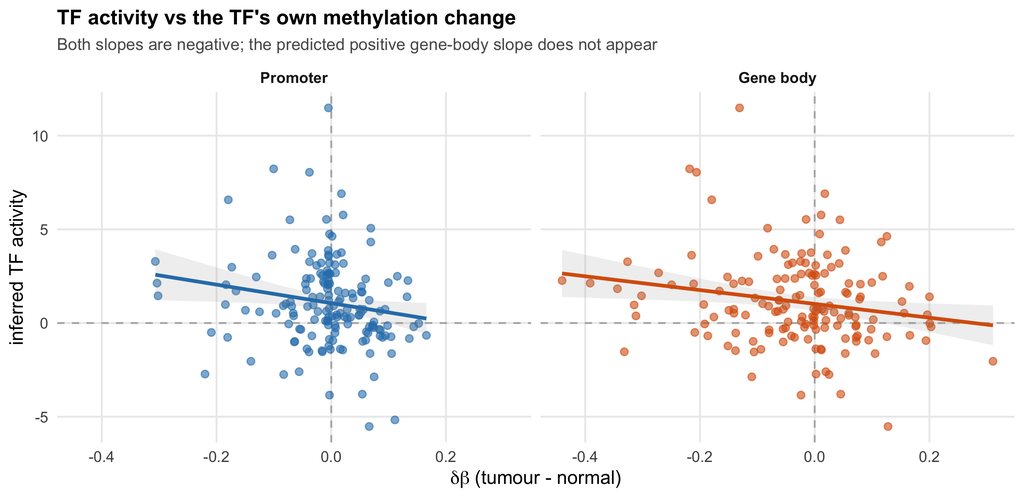

Inferred TF activity against the TF’s own methylation change. Both regions slope DOWNWARD: more methylation, lower activity. Under the design assumption the gene-body panel should slope upward.

```r
lng <- rbind(
  data.frame(tf = tb$tf, activity = tb$activity, dbeta = tb$prom_dbeta, region = "Promoter"),
  data.frame(tf = tb$tf, activity = tb$activity, dbeta = tb$body_dbeta, region = "Gene body"))
lng <- lng[is.finite(lng$dbeta) & is.finite(lng$activity), ]
lng$region <- factor(lng$region, levels = c("Promoter", "Gene body"))
ggplot(lng, aes(dbeta, activity, colour = region)) +
  geom_hline(yintercept = 0, colour = "grey70", linetype = 2) +
  geom_vline(xintercept = 0, colour = "grey70", linetype = 2) +
  geom_point(alpha = 0.6, size = 1.9) +
  geom_smooth(method = "lm", se = TRUE, linewidth = 1.1, alpha = 0.15) +
  scale_colour_manual(values = c(Promoter = COL_PROM, `Gene body` = COL_BODY), guide = "none") +
  facet_wrap(~ region) +
  labs(title = "TF activity vs the TF's own methylation change",
       subtitle = "Both slopes are negative; the predicted positive gene-body slope does not appear",
       x = expression(delta*beta~"(tumour - normal)"), y = "inferred TF activity")
```

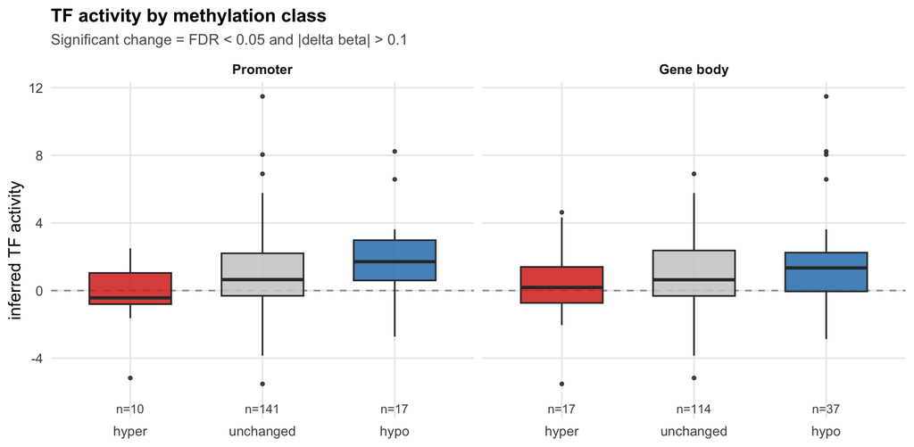

TF activity by methylation class. Promoter hypermethylation shifts activity down. Gene-body hypermethylation does not – its median sits near the unchanged group, and the negative fraction is close to a coin flip.

```r
cls <- function(db, fd) ifelse(is.finite(db) & is.finite(fd) & fd < 0.05 & abs(db) > 0.1,
                               ifelse(db > 0, "hyper", "hypo"), "unchanged")
box <- rbind(
  data.frame(activity = tb$activity, class = cls(tb$prom_dbeta, tb$prom_fdr), region = "Promoter"),
  data.frame(activity = tb$activity, class = cls(tb$body_dbeta, tb$body_fdr), region = "Gene body"))
box <- box[is.finite(box$activity), ]
box$region <- factor(box$region, levels = c("Promoter", "Gene body"))
box$class  <- factor(box$class,  levels = c("hyper", "unchanged", "hypo"))
lab <- do.call(rbind, lapply(split(box, list(box$region, box$class), drop = TRUE),
  function(d) data.frame(region = d$region[1], class = d$class[1], n = nrow(d),
                         med = median(d$activity))))
ggplot(box, aes(class, activity, fill = class)) +
  geom_hline(yintercept = 0, colour = "grey60", linetype = 2) +
  geom_boxplot(outlier.size = 0.9, width = 0.62, alpha = 0.85) +
  geom_text(data = lab, aes(x = class, y = -Inf, label = paste0("n=", n)),
            inherit.aes = FALSE, vjust = -0.6, size = 3.1, colour = "grey30") +
  ## extra room at the bottom so the n labels clear the outlier points
  scale_y_continuous(expand = expansion(mult = c(0.12, 0.05))) +
  scale_fill_manual(values = c(hyper = COL_POS, unchanged = COL_NULL, hypo = COL_NEG),
                    guide = "none") +
  facet_wrap(~ region) +
  labs(title = "TF activity by methylation class",
       subtitle = "Significant change = FDR < 0.05 and |delta beta| > 0.1",
       x = NULL, y = "inferred TF activity")
```

# 3. Do the regions carry independent information?

Tumours undergo broad hypomethylation that affects gene bodies especially, so a gene that gains promoter methylation may gain body methylation too. If the two measurements are correlated, an apparent body effect could be an echo of the promoter effect rather than a separate phenomenon.

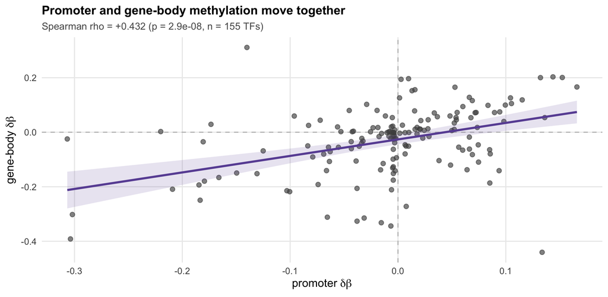

Promoter against gene-body methylation change, per transcription factor. The two are substantially correlated, so they cannot be treated as independent evidence.

```r
d <- tb[is.finite(tb$activity) & is.finite(tb$prom_dbeta) & is.finite(tb$body_dbeta), ]
ctpb <- cor.test(d$prom_dbeta, d$body_dbeta, method = "spearman")
ggplot(d, aes(prom_dbeta, body_dbeta)) +
  geom_hline(yintercept = 0, colour = "grey75", linetype = 2) +
  geom_vline(xintercept = 0, colour = "grey75", linetype = 2) +
  geom_point(alpha = 0.65, size = 2, colour = "grey30") +
  geom_smooth(method = "lm", se = TRUE, colour = "#6a51a3", fill = "#6a51a3", alpha = 0.15) +
  labs(title = "Promoter and gene-body methylation move together",
       subtitle = sprintf("Spearman rho = %+.3f (p = %.2g, n = %d TFs)",
                          ctpb$estimate, ctpb$p.value, nrow(d)),
       x = expression("promoter "*delta*beta), y = expression("gene-body "*delta*beta))
```

```r
pcor <- function(x, yy, z) {
  rx <- resid(lm(rank(x) ~ rank(z))); ry <- resid(lm(rank(yy) ~ rank(z)))
  ct <- cor.test(rx, ry)
  sprintf("%+.3f (p = %.3f)", ct$estimate, ct$p.value)
}
m <- lm(rank(activity) ~ rank(prom_dbeta) + rank(body_dbeta), data = d)
cf <- summary(m)$coefficients
knitr::kable(data.frame(
  Test = c("Activity ~ promoter (marginal)", "Activity ~ body (marginal)",
           "Activity ~ promoter, controlling for body",
           "Activity ~ body, controlling for promoter",
           "Joint rank model: promoter term", "Joint rank model: body term"),
  Result = c(sprintf("%+.3f", cor(d$activity, d$prom_dbeta, method = "spearman")),
             sprintf("%+.3f", cor(d$activity, d$body_dbeta, method = "spearman")),
             pcor(d$activity, d$prom_dbeta, d$body_dbeta),
             pcor(d$activity, d$body_dbeta, d$prom_dbeta),
             sprintf("t = %.2f (p = %.3f)", cf[2,3], cf[2,4]),
             sprintf("t = %.2f (p = %.3f)", cf[3,3], cf[3,4])),
  stringsAsFactors = FALSE),
  caption = sprintf("Disentangling the two regions (n = %d TFs with both measured).", nrow(d)))
```

Disentangling the two regions (n = 155 TFs with both measured).

| Test | Result |
| --- | --- |
| Activity ~ promoter (marginal) | -0.200 |
| Activity ~ body (marginal) | -0.173 |
| Activity ~ promoter, controlling for body | -0.140 (p = 0.081) |
| Activity ~ body, controlling for promoter | -0.098 (p = 0.223) |
| Joint rank model: promoter term | t = -1.75 (p = 0.082) |
| Joint rank model: body term | t = -1.22 (p = 0.225) |

Controlling for promoter methylation, the gene-body association drops to -0.098 (p = 0.223) — not distinguishable from zero. The promoter term weakens too but survives better. With 155 TFs this is underpowered to cleanly separate two correlated predictors, so the honest reading is **“gene body adds nothing detectable here”**, not “gene body is definitively inert”.

# Conclusions

**The predicted sign flip does not appear in this cohort.** Every line of evidence points the same way:

| Evidence | Promoter | Gene body | Predicted for body |
| --- | --- | --- | --- |
| Cis coupling, median $\rho$ | -0.040 | -0.031 | **positive** |
| Cis coupling, % negative | 59% | 56% | **minority** |
| vs TF activity, $\rho$ | -0.218 | -0.173 | **positive** |
| Hypermethylated TFs | activity down | ~unchanged | **activity up** |

Gene-body methylation behaves like a weaker version of promoter methylation, not like its mirror image. The two regions **do** differ significantly (paired Wilcoxon p = 0.0001), but in magnitude rather than direction.

## What this means for the prize function

Two consequences for `R/prizes.R`, of different severity:

1. **`concordance_bonus()` rewards a direction that is not present.** The function gives partial credit to *body-hyper + expression-up* as the expected pattern. In this cohort body-hyper trends with expression **down**. That term is crediting the wrong sign, so it adds noise where it intends to add evidence.
2. **Scoring the regions separately is still defensible, but for a different reason.** The justification in `CLAUDE.md` — opposite signs, so pooling cancels — does not hold here. What the data support instead is that gene-body methylation is a **weaker, partly redundant** version of the promoter signal (correlated at $\rho$ = +0.432, and contributing nothing once the promoter is accounted for). That argues for **down-weighting or dropping** the body term, not for sign-flipping it.

## Caveats

- **One cohort, one cancer type.** THCA is genomically quiet; positive body-methylation/expression coupling is better documented in highly proliferative tumours. This may not generalise, and the natural next step is a second TCGA cohort — which would also be the first real exercise of the cross-dataset comparison the project was built for.
- **Small TF subgroups.** Promoter hyper n = 10, body hyper n = 17. The subgroup medians are indicative, not conclusive.
- **The regulon sign convention matters** (section 2). The promoter association is significant under the standard convention and null under the strict one.
- **CpG island context is not modelled.** `Relation_to_UCSC_CpG_Island` (island / shore / shelf / open sea) is a stronger regulatory stratifier than the promoter/body split alone, and island-shore methylation is the more reliable signal. A region split that ignores it may be the wrong split entirely — a more promising revision than adjusting the current one.
- **Cross-reactive and SNP-overlapping probes are not excluded** (Chen 2013, Zhou 2017), which inflates apparent signal at affected loci in both regions.

# Reproducibility

```r
cat("Inputs:  results/{promoter,body}_methylation.tsv, results/cis_correlation_{paired,body}.tsv,\n",
    "         results/de_table.tsv, dorothea.tsv\n", sep = "")
```

```
## Inputs:  results/{promoter,body}_methylation.tsv, results/cis_correlation_{paired,body}.tsv,
##          results/de_table.tsv, dorothea.tsv
```

```r
cat("Derived: results/tf_activity_by_region.tsv\n\n")
```

```
## Derived: results/tf_activity_by_region.tsv
```

```r
cat(format(Sys.time(), "%Y-%m-%d %H:%M"), "|", R.version.string, "\n")
```

```
## 2026-08-17 19:35 | R version 4.6.1 (2026-06-24)
```